# ACMT Setup - Inspace

Amy Youngbloom

3/31/2022

### 1 Install the Docker

- Download and install the Docker
- Go to https://www.docker.com/
- Click on the “Get Started” button in the top right corner
- Click on the Download for Windows button and the download will start.
- Once the download completes, follow the instructions to complete installation.

## 2 Install WSL

*Download and WSL 2 Linux kernel Windows update + Go to https://docs.microsoft.com/en-us/windows/wsl/install-manual#step-4---download-the-linux-kernel-update-package + Click the link to download the WSL2 Linux kernel update package + The update will download, follow the steps to finalize the update

## 3 Download the ACMT Source code

- While the Docker is installing, you can navigate to git up to download the ACMT Source code
  - Go to https://github.com/2533245542/acmt-network
  - Click on the green ‘Code’ button, then select Download ZIP.
    - Unzip the ACMT Code to the documents folder on your computer (i.e., C:) and rename the folder to acmt-network.

[figure not shown]

Download ACMT source code from github

## 4 Edit the .env file

- In the ‘acmt-network’ folder, find the file named .env (If you do not see the file named .env on MacOS, you may need to press “command + shift + .” to make finder show you hidden files) and open it in Notepad.
  - Edit the GEOCODER_STATES line to include any state that you would like included:
  - i.e., GEOCODER_STATES=WA, MN, TX
  - To include all states, put GEOCODER_STATES=* (note that including all states will take a long time to install)
  - Save and close the file

## 5 Restart your computer

- After installing the docker and the WSL 2 Linux kernel update, restart your computer

## 6 Open Docker and update settings

- Once the docker is installed, open the docker, navigate to the settings and select the check box for ‘Use Docker Compose V2’:

[figure not shown]

Docker Settings: check the Use Docker Compose V2 option

### 7 Install the ACMT

- Open a command line terminal
  - In Windows: https://www.howtogeek.com/235101/10-ways-to-open-the-command-prompt-in-windows-10/
  - On a Mac: https://www.howtogeek.com/682770/how-to-open-the-terminal-on-a-mac/
- Navigate to the acmt-network folder in the terminal
  - Type cd then the folder path, for example:

[figure not shown]

Navigate to the folder path in the terminal/command prompt window

- You can also check the contents of the folder by typing ‘dir’, for example to ensure you are in the right folder.

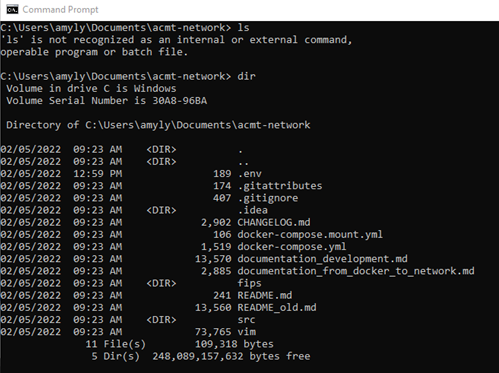

Show the contents of the folder in the terminal/command prompt window

### 8 Test the ACMT

- Once installation is complete, navigate to the docker and click the START button for the acmt-network container, if it’s not already greyed out (greyed out indicates it is already started). This starts the container and allows you to use the ACMT in the web browser

[figure not shown]

Start the acmt-network container in the Docker (play button)

[figure not shown]

- Note that this environment is your own customizable environment. When you close the window and stop the container in the Docker, your environment will be retained. However, if you upgrade your Docker, or uninstall Docker, your Rstudio environment will renew, so it is important to download and save all of the work you do in this Rstudio environment on your network so as to not lose any information. A good practice is to download and save your work after each session as a backup.
- Run the setup-acmt code and test the docker
  - Now we can open the TestDockerACMT.R file, which is located in the workspace folder, the first line of code in this file will appear as follows:

```r
source("setup-acmt.R")
```

- In this code chunk, the setup-acmt.R code will run several other code files to setup the ACMT Geocoder, and other tools built into the ACMT.
  - In some cases, there may be packages that were not automaticlaly included and you will get an error saying that package does not exist. In these cases, install any packages that do not currently exist in the environment, but are required as part of set up in order to move forward. For example, if you get an error saying that the package ‘leaflet’ does not exist or is not currently installed, you would run the following code:

```r
install.packages('leaflet')
```

- once you have successfully run the setup-acmt.R code file with the first line of code, you can now test the AMCT.
- To test the geocoder, enter an address that is from a state that you included in the .env file. For example, below is a Washington address, which assumes that you have the state of Washington loaded into the ACMT. If you do not, you will recieve an error message that reads, “The state of this address is not loaded into database”.

```r
# Test Geocoder
location <- geocode("1959 NE Pacific Street, Seattle, WA 98195")

head(location)
```

```
## $latitude
## [1] 47.65061
##
## $longitude
## [1] -122.308
##
## $rating
## [1] 0
```

- Along with the latitude and longitude, you are also given a rating for each geocode, with higher numbers indicating less accurate geocoding. Any rating that is 20 or higher is generally assumed to be an unrealiable geocode.
- Next we can use the latitude and longitude that were just generated to test the ACMT by pulling the interpoloated measure for total population from the ACS (B01001_001)

```r
# Test ACMT - pull Total population for given lat/long location
measures <- get_acmt_standard_array(long=location$longitude, lat=location$latitude, radius = 2000, codes_of_acs_variables_to_get = 'B01001_001', year=2019)
```

```r
data.frame(measures$names, round(measures$values, 2))
```

```
##    measures.names round.measures.values..2.
## 1 total_pop_count                  45579.87
```

### 9 Pulling non-ACS data

In addition to pulling ACS variables, the ACMT can also interpolate datat from other external data sources. The settings for several other data sources are already built into the ACMT. For example, below we can pull the Modified Retail Food Environment Index score for the location that we geocoded above. Note that the function requires at least one ACS variable, here we put total pop in (B01001_001)

```r
# Use external data source (the below uses mRFEI)
external_data_name_to_info_list <- list(
  mrfei=external_data_presets_mrfei
)


measures_for_2013_with_external_data_with_fill_missing <- get_acmt_standard_array(long=location$longitude, lat=location$latitude, radius_meters = 2000, year=2013, codes_of_acs_variables_to_get = 'B01001_001', #you still need to enter at least 1 ACS variable here!
                                                                                  external_data_name_to_info_list=external_data_name_to_info_list, fill_missing_GEOID_with_zero = TRUE)
```

```
## [1] "Read ACS columns"
## [1] B01001_001
## 303 Levels: B01001_001 B01001_002 B01001_003 B01001_004 ... C24060_002
## [1] "53033"
## [1] "called get_statecounty_tracts"
## [1] "Looking up tracts for state 53 , county 033"
## [1] "53033"
## [1] "called get_statecounty_tracts"
## [1] "Looking up tracts for state 53 , county 033"
```

```r
head(measures_for_2013_with_external_data_with_fill_missing)
```

```
##                 names       values
## 1     total_pop_count 40445.026351
## mrfei           mRFEI     8.309992
```

### 10 Pausing and restaring the ACMT

- Pausing the ACMT saves your work in the Rstudio environment. However, because any updates to the Docker may result in a loss of your work. A good practice is to download any progress and save locally before closing the ACMT.
- To pause the ACMT, save any work, then close the browser tab.
  - Next navigate to the Docker and click the ‘STOP’ button for the acmt-network container
- When you are ready to resume, reopen the Docker and press the start button for the acmt-network container (may take a few seconds to start).
  - Once the container is started, go to http://localhost:8787/ in your we browser.

### 11 Pulling data for Inspace

*For Inspace, we have list of various datasources from which you will be pulling. You can read more about the lists at the [Inspace repository site](https://aybloom.github.io/inspace/)* If you haven’t already done so, you can download the Inspace-specific R code, which is also accessed through the [Inspace repository site](https://aybloom.github.io/inspace/). + Scross down to the section titled, ‘Pull Measures from each dataset’, and click the link to download the zipped folder or R files.

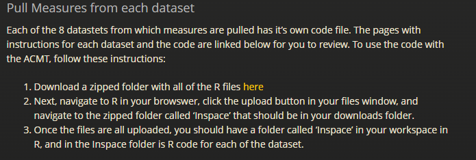

- In R on your browser, make sure you are viewing the ‘workspace’ folder in the ‘Files’ viewer on the botton right.
- Click the ‘Upload’ button and navigate to your downloads folder, where you will find the downloaded folder called “Inspace”

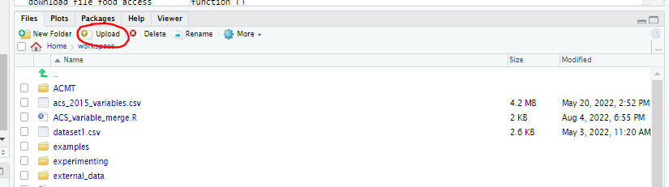

- You should now have a folder titled, ‘Inspace’ in your workspace folder, and inside the Inspace folder are the various R code scripts you will use when geocoding and pulling environmental measures.
- If your data is not yet geocoded, start with the file titled ‘ACMT-geocoder.Rmd’ and follow instructions in the document to geocoded your data.
- If your data is already geocoded, you can start with the ‘ACS Data Pull.Rmd’ to begin pulling American Community Survey data. Be sure your data is set up exactly as instructed in the code, with ‘lat’ and ‘long’ columns (note that R is case sensitive, so be sure the ‘l’ is lower case)

For additional instructions, visit the [Inspace repository site](https://aybloom.github.io/inspace/).